# AS10-2：研究是否有做臨床實驗

卓雍然 D994010001

2018-08-12 17:11:34

```r
packages = c(
  "dplyr","ggplot2","caTools","tm","SnowballC","ROCR","rpart",
  "rpart.plot","randomForest")
existing = as.character(installed.packages()[,1])
for(pkg in packages[!(packages %in% existing)]) install.packages(pkg)
```

```r
rm(list=ls(all=TRUE))
Sys.setlocale("LC_ALL","C")
```

```
## [1] "C"
```

```r
options(digits=5, scipen=10)

library(dplyr)
library(tm)
library(SnowballC)
library(ROCR)
library(caTools)
library(rpart)
library(rpart.plot)
library(randomForest)
```

### Problem 1 - Data Exploration

```r
D = read.csv("data/clinical_trial.csv", stringsAsFactors = F)
```

##### 1.1 The longest abstract

【P1.1】*How many characters are there in the longest abstract?*

```r
nchar(D$abstract) %>% max
```

```
## [1] 3708
```

##### 1.2 No abstract

【P1.2】*How many search results provided no abstract?*

```r
sum(nchar(D$abstract) == 0)
```

```
## [1] 112
```

##### 1.3 Shortest title

【P1.3】*What is the shortest title?*

```r
D$title[ which.min(nchar(D$title)) ]
```

```
## [1] "A decade of letrozole: FACE."
```

### Problem 2 - Preparing the Corpus

Because we have both title and abstract information for trials, we need to build two corpora instead of one. Name them `corpT` and `corpA`.

##### 2.1 Courps & DTM

```r
library(tm)
library(SnowballC)

# Corpus & DTM for Title
corpT = Corpus(VectorSource(D$title))
corpT = tm_map(corpT,  content_transformer(tolower))
corpT = tm_map(corpT, removePunctuation)
corpT = tm_map(corpT, removeWords, stopwords("english"))
corpT = tm_map(corpT, stemDocument)
dtmT = DocumentTermMatrix(corpT); dtmT
```

```
## <<DocumentTermMatrix (documents: 1860, terms: 2833)>>
## Non-/sparse entries: 23416/5245964
## Sparsity           : 100%
## Maximal term length: 49
## Weighting          : term frequency (tf)
```

```r
dtmT = removeSparseTerms(dtmT, 0.95); dtmT
```

```
## <<DocumentTermMatrix (documents: 1860, terms: 31)>>
## Non-/sparse entries: 10683/46977
## Sparsity           : 81%
## Maximal term length: 15
## Weighting          : term frequency (tf)
```

```r
dtmT = as.data.frame(as.matrix(dtmT))
```

【P2.1a】*How many terms remain in `dtmT` after removing sparse terms (aka how many columns does it have)?*

- 31

```r
corpA = Corpus(VectorSource(D$abstract))
corpA = tm_map(corpA,  content_transformer(tolower))
corpA = tm_map(corpA, removePunctuation)
corpA = tm_map(corpA, removeWords, stopwords("english"))
corpA = tm_map(corpA, stemDocument)
dtmA = DocumentTermMatrix(corpA); dtmA
```

```
## <<DocumentTermMatrix (documents: 1860, terms: 12335)>>
## Non-/sparse entries: 153239/22789861
## Sparsity           : 99%
## Maximal term length: 67
## Weighting          : term frequency (tf)
```

```r
dtmA = removeSparseTerms(dtmA, 0.95); dtmA
```

```
## <<DocumentTermMatrix (documents: 1860, terms: 335)>>
## Non-/sparse entries: 92007/531093
## Sparsity           : 85%
## Maximal term length: 15
## Weighting          : term frequency (tf)
```

```r
dtmA = as.data.frame(as.matrix(dtmA))
```

【P2.1b】*How many terms remain in `dtmA` after removing sparse terms?*

- 335

##### 2.2 Abstract is longer than title

【P2.2】*What is the most likely reason why `dtmA` has so many more terms than `dtmT`?*

- Abstracts tend to have many more words than titles

##### 2.3 The most frequent word in abstracts

【P2.3】*What is the most frequent word stem across all the abstracts?*

```r
which.max(colSums(dtmA))
```

```
## patient
##      17
```

### Problem 3 - Building a model

##### 3.1 Make column names

```r
colnames(dtmT) = paste0("T", colnames(dtmT))
colnames(dtmA) = paste0("A", colnames(dtmA))
```

【P3.1】*What was the effect of these functions?*

- Adding the letter T in front of all the title variable names and adding the letter A in front of all the abstract variable names.

##### 3.2 Combine DTMs & Add target varible

```r
dtm = cbind(dtmT, dtmA)
dtm$trial = D$trial
```

【P3.2】*How many columns are in this combined data frame?*

```r
ncol(dtm)
```

```
## [1] 367
```

##### 3.3 Splitting data

```r
library(caTools)
set.seed(144)
spl = sample.split(dtm$trial, 0.7)
train = subset(dtm, spl == TRUE)
test = subset(dtm, spl == FALSE)
```

【P3.3】*What is the accuracy of the baseline model on the training set?*

```r
table(train$trial) %>% prop.table
```

```
##
##       0       1
## 0.56068 0.43932
```

##### 3.4 CART Model

```r
library(rpart)
library(rpart.plot)
cart = rpart(trial~., train, method="class")
```

【P3.4】*What is the name of the first variable the model split on?*

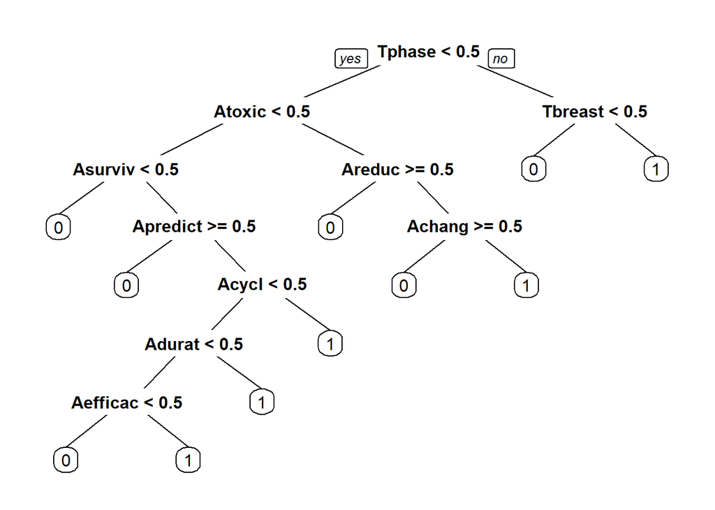

```r
prp(cart)
```

##### 3.5 The predicted probability

【P3.5】*What is the maximum predicted probability for any result?*

```r
pred = predict(cart)[,2]
max(pred)
```

```
## [1] 0.87189
```

##### 3.6 Similarity between testing & training data

【P3.6】*Without running the analysis, how do you expect the maximum predicted probability to differ in the testing set?*

- The maximum predicted probability will likely be exactly the same in the testing set.

##### 3.7 Accuracy Matrices

Use a threshold probability of 0.5

```r
table(train$trial, pred > 0.5)
```

```
##
##     FALSE TRUE
##   0   631   99
##   1   131  441
```

【P3.7a】*What is the training set accuracy of the CART model?*

```r
(631+441)/(631+441+131+99)
```

```
## [1] 0.82335
```

【P3.7b】*What is the training set sensitivity of the CART model?*

```r
441/(131+441)
```

```
## [1] 0.77098
```

【P3.7c】*What is the training set specificity of the CART model?*

```r
631/(631+99)
```

```
## [1] 0.86438
```

### Problem 4 - Evaluating the model on the testing set

##### 4.1 Test Accuracy

【P4.1】*What is the test accuracy?*

```r
pred = predict(cart,test)[,2]
table(test$trial, pred > 0.5) %>% {sum(diag(.)) / sum(.)}
```

```
## [1] 0.75806
```

##### 4.2 Test AUC

【P4.2】*What is the test AUC?*

```r
colAUC(pred, test$trial)
```

```
##            [,1]
## 0 vs. 1 0.83711
```

### Problem 5 - Decision Tradeoffs

The research procedure is …

- Step 1: use model to select articles of “predict trial = 1”
- Step 2: manually review the selected articles
- Step 3: extract data from suitable articles (for further analysis)

##### 5.1 Cost of False Negative

【P5.1】*What is the cost associated with the model in Step 1 making a false negative prediction?*

- A paper that should have been included in Set A will be missed, affecting the quality of the results of Step 3

##### 5.2 Cost of False Posituve

【P5.2】*What is the cost associated with the model in Step 1 making a false positive prediction?*

- A paper will be mistakenly added to Set A, yielding additional work in Step 2 of the process but not affecting the quality of the results of Step 3.

##### 5.3 The Threshold

【P5.3】*Given the costs associated with false positives and false negatives, which of the following is most accurate?*

- A false negative is more costly than a false positive; the decision maker should use a probability threshold less than 0.5 for the machine learning model.